# DATA605 Homework 7

Keith Colella

2023-10-16

```r
library(tidyverse)
```

# Question 1

Let $X_1$, $X_2$, . . . , $X_n$ be n mutually independent random variables, each of which is uniformly distributed on the integers from 1 to $k$. Let $Y$ denote the minimum of the $X_i$’s. Find the distribution of $Y$.

### Response

Our goal is to find a function that describes the distribution of $Y$s, i.e. the probability mass function $P(Y = y)$. We can start by defining the cumulative distribution of $Y$, i.e. $F(Y) = P(Y \leq y)$. Because $Y$ represents the minimum of each $X_i$, the probability that $Y$ will be less than or equal to some value $y$ is the same as the probability that at least one of the random variables $X$ is less than or equal to $y$. In other words, its the compliment of the joint probability that all variables $X$ are greater than $y$.

$$P(Y \leq y) = 1 - P(X_1 > y) \times
P(X_2 > y) \times \ ...\ \times P(X_n > y)$$

Each individual variable $X$ is uniformly distributed, so $P(X_i > y) = (k-y)/k$, and the joint probability can be expressed as $P(Y>y) = [(k-y)/k]^n$, and our CDF can be expressed as $P(Y \leq y) = 1 - [(k-y)/k]^n$.

Because all variables $X$ are discrete, we can define the probability that $Y$ is a specific value $y$ as the difference between the CDFs given $y$ and $y-1$. In other words:

$$P(Y = y) = P(Y \leq y) - P(Y \leq y -
1)$$

If we substitute our CDF definitions above, we get the following.

$$P(Y = y) = 1 - (\frac{k-y}{k})^n - [1 -
(\frac{k-(y-1)}{k})^n]$$

We can rearrange this and simplify as follows.

$$P(Y = y) = (\frac{k-y+1}{k})^n -
(\frac{k-y}{k})^n$$

We can put together a function to test this distribution for certain values of $n$ and $k$, given a certain value $y$. We generate plots for different combinations of $n$ and $k$ to observe the varied distributions.

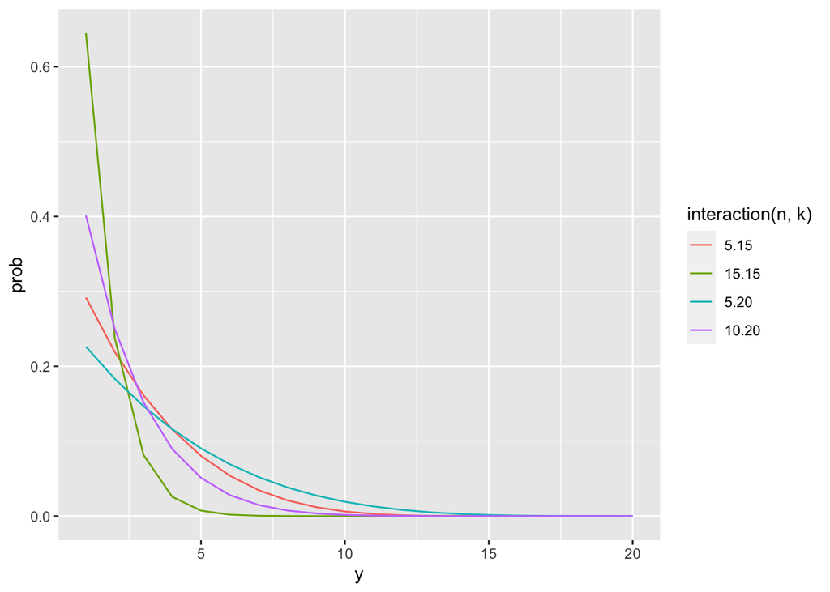

```r
Y_pmf <- function(y, n, k) {
  prob <- ((k - y + 1) / k)^n - ((k - y) / k)^n
  return(prob)
}

n_values <- c(5,10,5,15)
k_values <- c(20,20,15,15)
results <- data.frame()

for (i in 1:4) {
  n <- n_values[i]
  k <- k_values[i]
  for (y in 1:k) {
    prob <- Y_pmf(y, n, k)
    result <- list(y = y, n = n, k = k, prob = prob)
    results <- rbind(results, result)
  }
}

results %>%
  ggplot(aes(y, prob, color = interaction(n, k))) +
  geom_line()
```

# Question 2

Your organization owns a copier (future lawyers, etc.) or MRI (future doctors). This machine has a manufacturer’s expected lifetime of 10 years. This means that we expect one failure every ten years. (Include the probability statements and R Code for each part.)

## Part A

What is the probability that the machine will fail after 8 years? Provide also the expected value and standard deviation. Model as a geometric. *Hint: the probability is equivalent to not failing during the first 8 years.*

### Response

Here, we can define the machine failing as a “success”, and each year as a separate “trial”. In this case, our probability of success per trial (i.e. the likelihood of failure each year) is 1/10. If we are looking for the probability that the machine fails after 8 years, then we are looking for $P(X > 8)$.

We can use the CDF of the geometric distribution to find $P(X\leq 8)$, then take the complement (i.e. $1 - P(X\leq 8)$) to find $P(X > 8)$. The CDF is defined as $F(x) = P(X \leq x) = 1 - (1 - p)^{x+1}$, so we simply need to plug in our values for $p$ and $x$ (i.e., 1/10 and 8, respectively).

The expected value and standard deviation of the geometric distribution are defined as $1/p$ and $\sqrt{(1 - p) / p^2}$.

```r
# Parameters
p <- 1/10
x <- 8

# Calculations
probability <- 1 - (1 - (1 - p)^(x+1) )
expected_value <- 1/p
standard_deviation <- sqrt( (1-p) / p^2 )

# Results
cat("Probability of failure after 8 years:", probability, "\n")
```

```
## Probability of failure after 8 years: 0.3874205
```

```r
cat("Expected value:", expected_value, "\n")
```

```
## Expected value: 10
```

```r
cat("Standard deviation:", standard_deviation, "\n")
```

```
## Standard deviation: 9.486833
```

We’ll check our results with the `pgeom` function.

```r
probability <- 1 - pgeom(x, prob = p)
cat("Probability of failure after 8 years:", probability, "\n")
```

```
## Probability of failure after 8 years: 0.3874205
```

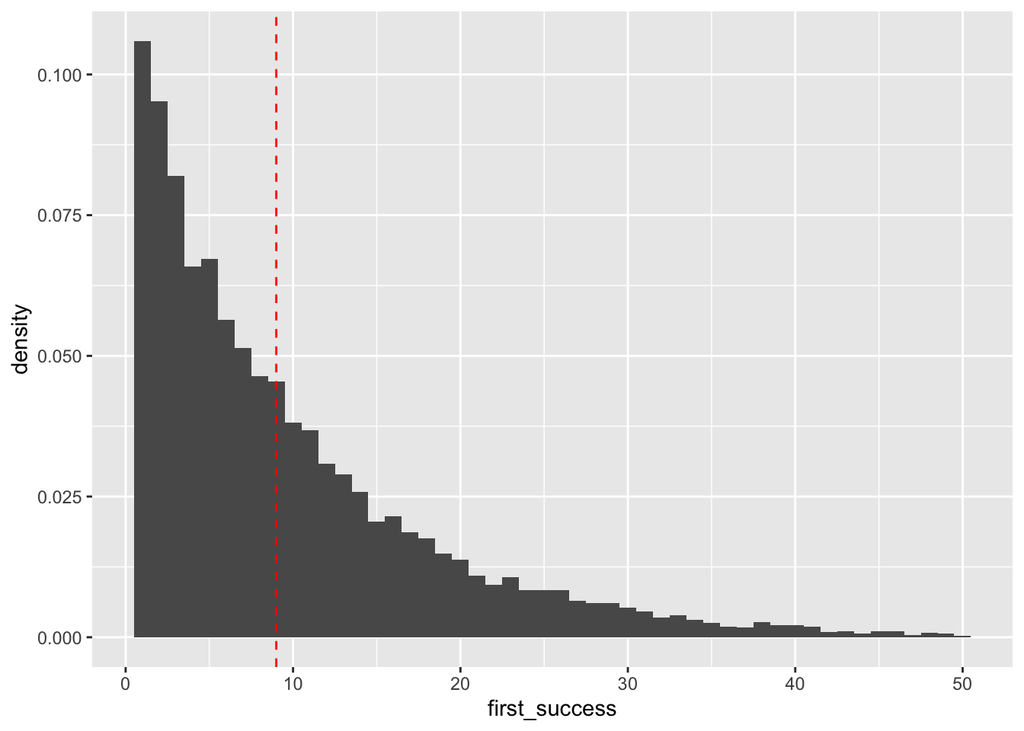

```r
n_sims <- 10000
n_samples <- 50
p <- 1/10
results <- data.frame()

for (sim in 1:n_sims) {
  samples <- sample(0:1, size = n_samples, replace = TRUE, prob = c(1-p, p))
  first_success <- min(which(samples == 1))
  result <- list(sim = sim, first_success = first_success)
  results <- rbind(results, result)
}

results %>%
  ggplot(aes(first_success, ..density..)) +
  geom_histogram(bins = 50) +
  geom_vline(aes(xintercept = 9), linetype="dashed", color="red")
```

To my surprise, the plot conforms to our earlier results. Surprising, but this helps convince me!

## Part B

What is the probability that the machine will fail after 8 years?. Provide also the expected value and standard deviation. Model as an exponential.

### Response

Again, we can define the machine failing as a “success”. We don’t have discrete trials when modeling as an exponential process, but instead use our probability of success as a rate of success. This rate (i.e. $\lambda$) is 1/10. If we are looking for the probability that the machine fails after 8 years, then we are looking for $P(X > 8)$.

The CDF of the exponential distribution is defined as $F(x) = P(X \leq x) = 1 - e^{-\lambda\,x}$, so we simply need to plug in our values for $\lambda$ and $x$ (i.e., 1/10 and 8, respectively). Again, we’ll take the compliment (i.e. $1 - P(X\leq 8)$) to find $P(X > 8)$.

```r
# Parameters
lambda <- 1/10
x <- 8

# Calculations
probability <- 1 - (1 - exp(-lambda*x))
expected_value <- 1/lambda
standard_deviation <- sqrt( 1/lambda^2 )

# Results
cat("Probability of failure after 8 years:", probability, "\n")
```

```
## Probability of failure after 8 years: 0.449329
```

```r
cat("Expected value:", expected_value, "\n")
```

```
## Expected value: 10
```

```r
cat("Standard deviation:", standard_deviation, "\n")
```

```
## Standard deviation: 10
```

We’ll check our results with the `pexp` function.

```r
probability <- 1 - pexp(x, rate = lambda)
cat("Probability of failure after 8 years:", probability, "\n")
```

```
## Probability of failure after 8 years: 0.449329
```

Our results match!

## Part C

What is the probability that the machine will fail after 8 years? Provide also the expected value and standard deviation. Model as a binomial. *Hint: 0 success in 8 years.*

### Response

As with the first problem, we can define the machine failing as a “success”, and each year as a separate “trial”. In this case, our probability of success per trial (i.e. the likelihood of failure each year) is 1/10. If we are looking for the probability that the machine fails after 8 years, then we define our random variable as $X$~$B(n,p)$ with $n=8$ and $p=0.1$. Finally, we are looking for the probability that $X$ remains zero across all 8 trials, i.e. $P(X = 0)$.

We can use the PMF of the binomial distribution to find $P(X = 0)$, defined as $\binom{n}{k}p^k(1-p)^{n-k}$. The expected value and standard deviation of are defined as $n*p$ and $\sqrt{n*p*(1-p)}$.

```r
# Parameters
p <- 1/10
n <- 8
k <- 0

# Calculations
probability <- choose(n,k) * p^k * (1-p)^(n-k)
expected_value <- n*p
standard_deviation <- sqrt( n*p*(1-p) )

# Results
cat("Probability of failure after 8 years:", probability, "\n")
```

```
## Probability of failure after 8 years: 0.4304672
```

```r
cat("Expected value:", expected_value, "\n")
```

```
## Expected value: 0.8
```

```r
cat("Standard deviation:", standard_deviation, "\n")
```

```
## Standard deviation: 0.8485281
```

We’ll check our results with the `dbinom` function.

```r
probability <- dbinom(0, n, p)
cat("Probability of failure after 8 years:", probability, "\n")
```

```
## Probability of failure after 8 years: 0.4304672
```

Our results match!

## Part D

What is the probability that the machine will fail after 8 years? Provide also the expected value and standard deviation. Model as a Poisson.

### Response

Typically, the Poisson distribution is used to estimate the probability of a certain number of occurrences happening over a fixed period. Here, we are looking specifically if the number of occurrences is zero over an 8-year period. If start with the same annual lambda as we had in Part B (1/10), we can convert this to an 8-year lambda, which we’ll dub $\lambda_8$. We can then calculate the probability that $X$ remains zero across the 8-year period, i.e. $P(X = 0)$ given $\lambda_8$.

The PMF of the Poisson distribution is defined as $P(X = x) = (\lambda^x e^{-\lambda}) / x!$. The expected value and standard deviation are defined as $lambda$ and $\sqrt{\lambda}$.

```r
# Parameters
lambda <- 1/10
lambda_8 <- lambda * 8
x <- 0

# Calculations
probability <- lambda_8^x * exp(-lambda_8) / factorial(x)
expected_value <- lambda
standard_deviation <- sqrt(lambda)
expected_value_8 <- lambda_8
standard_deviation_8 <- sqrt(lambda_8)

# Results
cat("Probability of failure after 8 years:", probability, "\n\n")
```

```
## Probability of failure after 8 years: 0.449329
```

```r
cat("Expected number of failures for 1-year period:", expected_value, "\n")
```

```
## Expected number of failures for 1-year period: 0.1
```

```r
cat("Standard deviation for 1-year period:", standard_deviation, "\n\n")
```

```
## Standard deviation for 1-year period: 0.3162278
```

```r
cat("Expected number of failures for 8-year period:", expected_value_8, "\n")
```

```
## Expected number of failures for 8-year period: 0.8
```

```r
cat("Standard deviation for 8-year period:", standard_deviation_8, "\n")
```

```
## Standard deviation for 8-year period: 0.8944272
```

Finally, we’ll check out results with `dpois`.

```r
probability <- dpois(x, lambda_8)
cat("Probability of failure after 8 years:", probability)
```

```
## Probability of failure after 8 years: 0.449329
```

Another match!